# Data Cleaning and Summary

Havisha Khurana

11/2/2021

Let’s load packages

Let’s read the data.

```r
hnb <- import(here("data","Harassment and Bullying.csv")) %>%
    as_tibble()
hnb_col <- colnames(hnb)
```

Quick summary:

*Note to self:* `grep()` saves the indices of columns

First, let’s change all negative numbers to NA.

```r
remove_neg <- function (x) ifelse(x < 0, NA, x)
hnb_pos <- hnb %>%
    mutate(across(c(9:145), remove_neg))
```

Nice!

Let’s make a shorter dataset to work with. I have allegations, reported and disciplined for the following intents: sex, race and disability. Let’s just take these forward.

```r
cat_sum <- function(x) rowSums(select(hnb_pos, starts_with(x)), na.rm = TRUE)

hnb_sub <- hnb_pos %>%
    select("LEA_STATE","LEA_NAME","COMBOKEY", starts_with(c("SCH_HBALLEGATIONS","TOT_HBREPORTED","TOT_HBDISCIPLINED"))) %>%
    mutate(TOT_HBREPORTED_SEX = cat_sum("TOT_HBREPORTED_SEX"),
           TOT_HBREPORTED_RAC = cat_sum("TOT_HBREPORTED_RAC"),
           TOT_HBREPORTED_DIS = cat_sum("TOT_HBREPORTED_DIS"),
           TOT_HBDISCIPLINED_SEX = cat_sum("TOT_HBDISCIPLINED_SEX"),
           TOT_HBDISCIPLINED_RAC = cat_sum("TOT_HBDISCIPLINED_RAC"),
           TOT_HBDISCIPLINED_DIS = cat_sum("TOT_HBDISCIPLINED_DIS"),
           TOT_HBALLEGATIONS = cat_sum("SCH_HBALLEGATIONS"),
           TOT_HBREPORTED = cat_sum("TOT_HBREPORTED"),
           TOT_HBDISCIPLINED = cat_sum("TOT_HBDISCIPLINED")) %>%
    filter(if_any(c(27:29),~ . > 0))
```

That looks like a neat data set. We have total 29 variables - 3 are identifiers and rest are numeric. Also, we have filtered out rows where all numeric columns are 0.

Let’s find some summary of cols.

```r
skim(hnb_sub)
```

Data summary

| Name | hnb_sub |
| --- | --- |
| Number of rows | 23421 |
| Number of columns | 29 |
| _______________________ |  |
| Column type frequency: |  |
| character | 3 |
| numeric | 26 |
| ________________________ |  |
| Group variables | None |

**Variable type: character**

| skim_variable | n_missing | complete_rate | min | max | empty | n_unique | whitespace |
| --- | --- | --- | --- | --- | --- | --- | --- |
| LEA_STATE | 0 | 1 | 2 | 2 | 0 | 52 | 0 |
| LEA_NAME | 0 | 1 | 3 | 50 | 0 | 7010 | 0 |
| COMBOKEY | 0 | 1 | 12 | 12 | 0 | 23421 | 0 |

**Variable type: numeric**

| skim_variable | n_missing | complete_rate | mean | sd | p0 | p25 | p50 | p75 | p100 | hist |
| --- | --- | --- | --- | --- | --- | --- | --- | --- | --- | --- |
| SCH_HBALLEGATIONS_SEX | 15 | 1 | 2.36 | 4.56 | 0 | 0 | 1 | 3 | 138 | ▇▁▁▁▁ |
| SCH_HBALLEGATIONS_RAC | 14 | 1 | 1.27 | 3.12 | 0 | 0 | 0 | 1 | 88 | ▇▁▁▁▁ |
| SCH_HBALLEGATIONS_DIS | 11 | 1 | 0.60 | 3.12 | 0 | 0 | 0 | 0 | 183 | ▇▁▁▁▁ |
| SCH_HBALLEGATIONS_ORI | 12 | 1 | 0.79 | 2.37 | 0 | 0 | 0 | 1 | 102 | ▇▁▁▁▁ |
| SCH_HBALLEGATIONS_REL | 12 | 1 | 0.26 | 1.74 | 0 | 0 | 0 | 0 | 88 | ▇▁▁▁▁ |
| TOT_HBREPORTED_SEX_M | 58 | 1 | 0.66 | 1.88 | 0 | 0 | 0 | 1 | 50 | ▇▁▁▁▁ |
| TOT_HBREPORTED_SEX_F | 61 | 1 | 1.26 | 2.63 | 0 | 0 | 0 | 2 | 89 | ▇▁▁▁▁ |
| TOT_HBREPORTED_RAC_M | 39 | 1 | 0.67 | 1.82 | 0 | 0 | 0 | 1 | 48 | ▇▁▁▁▁ |
| TOT_HBREPORTED_RAC_F | 39 | 1 | 0.40 | 1.32 | 0 | 0 | 0 | 0 | 73 | ▇▁▁▁▁ |
| TOT_HBREPORTED_DIS_M | 19 | 1 | 0.28 | 1.25 | 0 | 0 | 0 | 0 | 110 | ▇▁▁▁▁ |
| TOT_HBREPORTED_DIS_F | 19 | 1 | 0.14 | 0.70 | 0 | 0 | 0 | 0 | 34 | ▇▁▁▁▁ |
| TOT_HBDISCIPLINED_SEX_M | 5 | 1 | 1.70 | 3.14 | 0 | 0 | 1 | 2 | 60 | ▇▁▁▁▁ |
| TOT_HBDISCIPLINED_SEX_F | 5 | 1 | 0.32 | 1.20 | 0 | 0 | 0 | 0 | 55 | ▇▁▁▁▁ |
| TOT_HBDISCIPLINED_RAC_M | 3 | 1 | 0.86 | 2.20 | 0 | 0 | 0 | 1 | 60 | ▇▁▁▁▁ |
| TOT_HBDISCIPLINED_RAC_F | 3 | 1 | 0.23 | 1.03 | 0 | 0 | 0 | 0 | 40 | ▇▁▁▁▁ |
| TOT_HBDISCIPLINED_DIS_M | 2 | 1 | 0.41 | 1.98 | 0 | 0 | 0 | 0 | 76 | ▇▁▁▁▁ |
| TOT_HBDISCIPLINED_DIS_F | 2 | 1 | 0.12 | 0.92 | 0 | 0 | 0 | 0 | 71 | ▇▁▁▁▁ |
| TOT_HBREPORTED_SEX | 0 | 1 | 1.92 | 3.82 | 0 | 0 | 1 | 2 | 123 | ▇▁▁▁▁ |
| TOT_HBREPORTED_RAC | 0 | 1 | 1.07 | 2.76 | 0 | 0 | 0 | 1 | 104 | ▇▁▁▁▁ |
| TOT_HBREPORTED_DIS | 0 | 1 | 0.42 | 1.72 | 0 | 0 | 0 | 0 | 127 | ▇▁▁▁▁ |
| TOT_HBDISCIPLINED_SEX | 0 | 1 | 2.01 | 3.88 | 0 | 0 | 1 | 2 | 95 | ▇▁▁▁▁ |
| TOT_HBDISCIPLINED_RAC | 0 | 1 | 1.10 | 2.92 | 0 | 0 | 0 | 1 | 91 | ▇▁▁▁▁ |
| TOT_HBDISCIPLINED_DIS | 0 | 1 | 0.52 | 2.71 | 0 | 0 | 0 | 0 | 140 | ▇▁▁▁▁ |
| TOT_HBALLEGATIONS | 0 | 1 | 5.28 | 10.22 | 0 | 1 | 2 | 6 | 425 | ▇▁▁▁▁ |
| TOT_HBREPORTED | 0 | 1 | 3.41 | 6.22 | 0 | 1 | 2 | 4 | 187 | ▇▁▁▁▁ |
| TOT_HBDISCIPLINED | 0 | 1 | 3.63 | 7.03 | 0 | 1 | 2 | 4 | 268 | ▇▁▁▁▁ |

This is super interesting! Some conclusions:

- Allegations are highest, followed by disciplined and then reported. Probably, some teacher/adult saw the incident and disciplined the students involved, and hence things were not reported. Or, one student reported multiple people, hence the whole group was disciplined.
- Allegation, reported and disciplined have highest raw count for the ‘Disability’ intent, followed by ‘sex’ and ‘race’. However, the mean in all categories follow the order: ‘sex’, ‘race’ and ‘disability’
- In reported, often female students report more frequencty for ‘sex’ intent, but male students report more often for ‘race’ and ‘disability’
- In disciplined, for all intents, male students are more often disciplined than female students.

Let’s do some plots now.

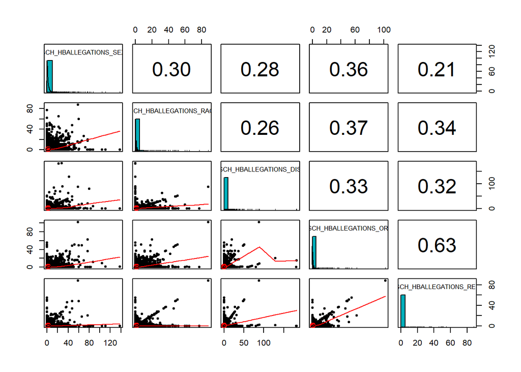

```r
pairs.panels(hnb_sub[,4:8],
             method = "pearson", # correlation method
             hist.col = "#00AFBB",
             density = TRUE,  # show density plots
             ellipses = TRUE # show correlation ellipses
             )
```

```r
#pairs(hnb_sub[,4:8], pch = 19, lower.panel = NULL)
#plotmatrix(hnb_sub[,27:29], colour="gray20")
```

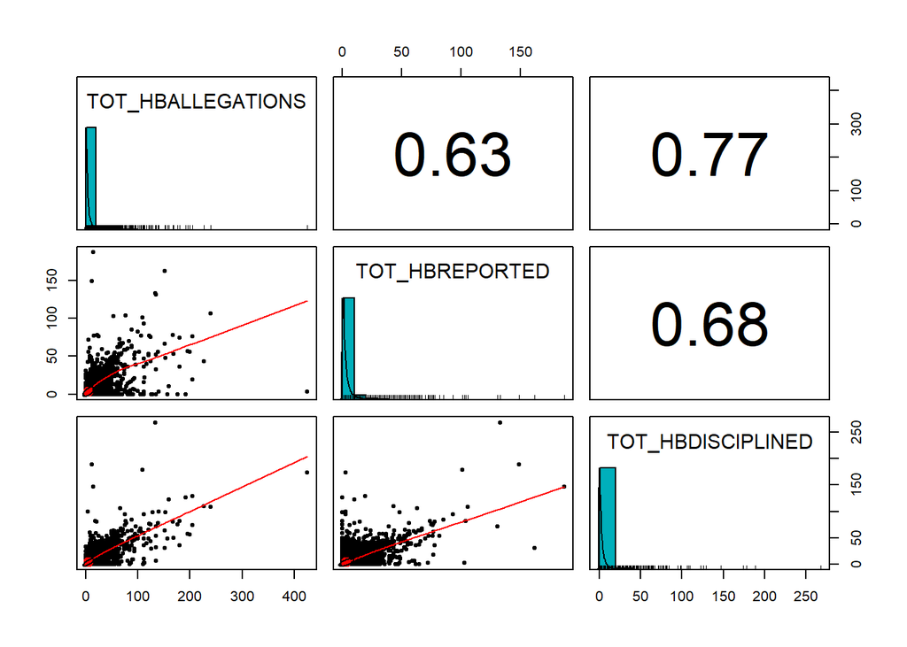

```r
pairs.panels(hnb_sub[,27:29],
             method = "pearson", # correlation method
             hist.col = "#00AFBB",
             density = TRUE,  # show density plots
             ellipses = TRUE # show correlation ellipses
             )
```

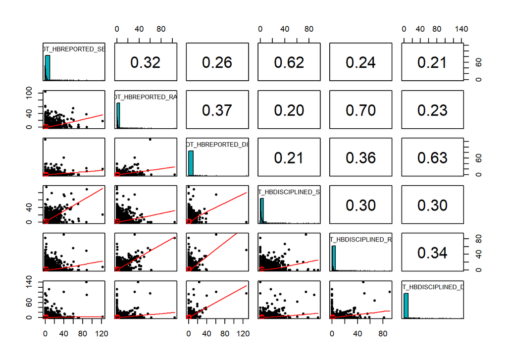

```r
pairs.panels(hnb_sub[,21:26],
             method = "pearson", # correlation method
             hist.col = "#00AFBB",
             density = TRUE,  # show density plots
             ellipses = TRUE # show correlation ellipses
             )
```

Let’s look at state-wide boxplot, but each point represents the district

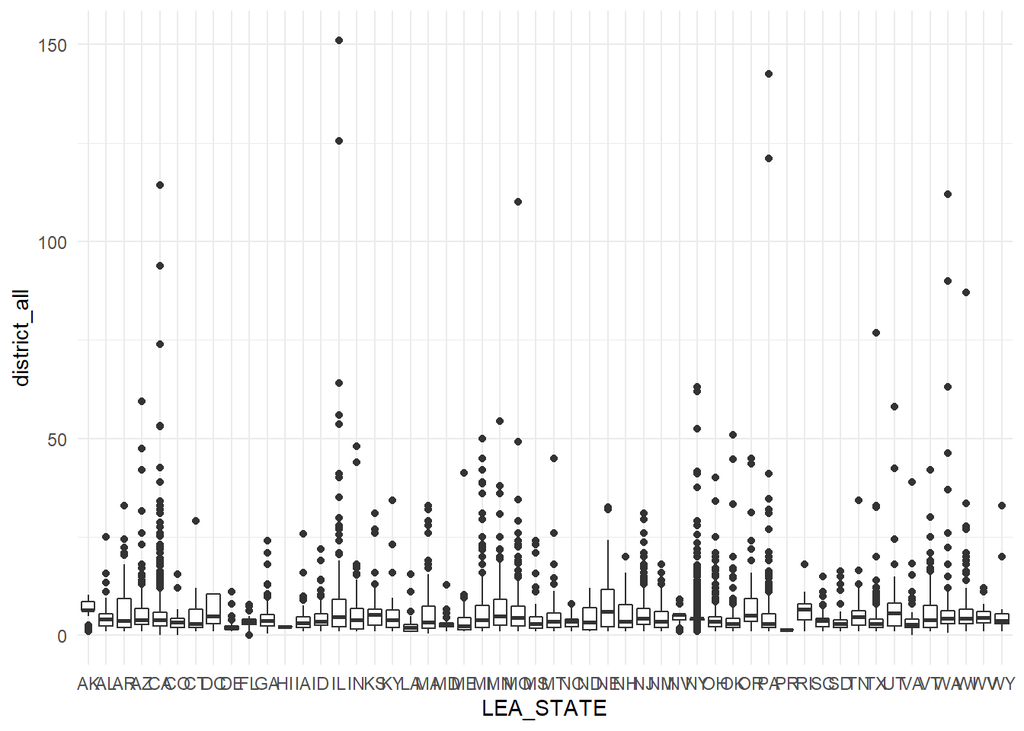

```r
hnb_sub2 <- hnb_sub %>%
    group_by(LEA_NAME) %>%
    mutate(district_all = mean(TOT_HBALLEGATIONS),
           district_rep = mean(TOT_HBREPORTED),
           district_dis = mean(TOT_HBDISCIPLINED))

hnb_sub2 %>%
    group_by(LEA_STATE) %>%
    ggplot() +
    geom_boxplot(aes(LEA_STATE, district_all))
```